# Bitcoin & Etherium historical data

## Features

**AdrActCnt** - the sum count of unique addresses that were active in the network (either as a destination or source of a ledger change) that day. All parties in a ledger change action (source and destination) are counted. Individual addresses are not double-counted if previously active.

**AssetEODCompletionTime** - last fully calculated EOD metrics time.

**BlkCnt** - the sum count of blocks created that day that were included in the main (base) chain.

**BlkSizeByte** - Block, size, bytes.

**BlkSizeMeanByte** - the mean size (in bytes) of all blocks created that day.

**CapMVRVCur** - The ratio of the sum USD value of the current supply to the sum "realized" USD value of the current supply. Computed as CapMrktCurUSD / CapRealUSD.

The intuition behind the creation of this ratio was to divide a price function by a ‘fundamental’ as proxied by Realized Capitalization (see Capitalization, realized, USD). This gives you a ratio potentially indicating periods of overvaluation (when network value far exceeds its historical relationship to realized cap) and undervaluation. Realized cap is a potent fundamental as it can be understood as the average cost basis for holders at a given time, so the ratio of the two indicates whether holders are underwater or not, giving insight into aggregate sentiment.

**CapMrktCurUSD** - the sum USD value of the current supply. Also referred to as network value or market capitalization.

**CapRealUSD** - the sum USD value based on the USD closing price on the day that a native unit last moved (i.e., last transacted) for all native units.

**DiffMean** - the mean difficulty of finding a hash that meets the protocol-designated requirement (i.e., the difficulty of finding a new block) that day. The requirement is unique to each applicable cryptocurrency protocol. Difficulty is adjusted periodically by the protocol as a function of how much hashing power is being deployed by miners.

**FeeMeanNtv** - the mean fee per transaction in native units that day.

**FeeMeanUSD** - the USD value of the mean fee per transaction that day.

**FeeMedNtv** - the median fee per transaction in native units that day.

**FeeMedUSD** - the USD value of the median fee per transaction that day.

**FeeTotNtv** - the sum of all fees paid to miners, transaction validators, stakers and/or block producers that day. In certain cryptonetworks, fees might be burned (destroyed), but they are still accounted for in this metric.

**FeeTotUSD** - the sum of all fees paid to miners, transaction validators, stakers and/or block producers that day. In certain cryptonetworks, fees might be burned (destroyed), but they are still accounted for in this metric.

**HashRate** - the mean rate at which miners are solving hashes that day. Hash rate is the speed at which computations are being completed across all miners in the network. The unit of measurement varies depending on the protocol.

**IssContNtv** - the sum of USD value issued that day. Only those native units that are issued by a protocol-mandated continuous emission schedule are included.

**IssContPctAnn** - the percentage of new native units (continuous) issued on that day, extrapolated to one year (i.e., multiplied by 365), and divided by the current supply on that day. Sometimes referred to as the annual inflation rate.

**IssContUSD** - Issuance, continuous, USD.

**IssTotNtv** - the sum of all new native units issued that day.

**IssTotUSD** - the sum USD value of all new native units issued that day.

**NVTAdj** - the ratio of the network value (or market capitalization, current supply) divided by the adjusted transfer value. Also referred to as NVT.

It compares market capitalization to on-chain transactional usage. Blockchains with high usage relative to market cap have a higher NVT. In this sense it can be understood as the opposite of velocity.

**NVTAdj90** - the ratio of the network value (or market capitalization, current supply) to the 90-day moving average of the adjusted transfer value. Also referred to as NVT.

**PriceBTC** - the fixed closing price of the asset as of 00:00 UTC the following day (i.e., midnight UTC of the current day) denominated in BTC.

**PriceUSD** - the fixed closing price of the asset as of 00:00 UTC the following day (i.e., midnight UTC of the current day) denominated in USD. This price is generated by Coin Metrics' fixing/reference rate service.

**ROI1yr** - ROI (return on investment), percent, 1yr.

**ROI30d** - ROI (return on investment), percent, 30d.

**SplyCur** - the sum of all native units ever created and currently visible on the ledger (i.e., issued) as of that day. For account-based protocols, only accounts with positive balances are counted.

**SplyExpFut10yrCMBI** - the sum of all native units counting current supply and including all those expected to be issued over the next 10 years from that day if the current known continuous issuance schedule is followed. Future expected hard-forks that will change the continuous issuance are not considered until the day they are activated/enforced. The CMBI version of this metric takes extra steps to guarantee heuristcs are uniformly applied to various cryptoassets.

**SplyFF** - the sum of all native units ever created and visible on the ledger excluding native units held closely by company insiders, controlling investors and long term strategic holders as of that day.

**TxCnt** - the sum count of transactions that day. Transactions represent a bundle of intended actions to alter the ledger initiated by a user (human or machine). On certain occasions, transactions are counted regardless of whether they result in the transfer of native units or not. As long as such transactions are recorded on the chain, they will be included in the calculation of this metric. Changes to the ledger algorithmically mandated by the protocol, such as coinbase transactions or post-launch new issuance, are not included here.

**TxTfrCnt** - the sum count of tranfers that interval.

Example Consider a single Bitcoin transaction that represents a company's payroll. The company broadcasting this transaction spends one input and generates 12 UTXOs, one for each of its employees. In this example, that transaction would entail 12 transfers.

**TxTfrValAdjNtv** - the sum of native units transferred that day removing noise and certain artifacts.

**TxTfrValAdjUSD** - the USD value of the sum of native units transferred that day removing noise and certain artifacts.

**TxTfrValMeanNtv** - the sum value of native units transferred divided by the count of transfers (i.e., the mean size of a transfer) between distinct addresses that interval.

**TxTfrValMeanUSD** - the sum USD value of native units transferred divided by the count of transfers (i.e., the mean "size" in USD of a transfer) that day.

**TxTfrValMedNtv** - the median count of native units transferred per transfer (i.e., the median "size" of a transfer) that day.

**TxTfrValMedUSD** - the median USD value transferred per transfer (i.e., the median "size" in USD of a transfer) that day.

**TxTfrValNtv** - the sum of native units transferred (i.e., the aggregate "size" of all transfers) that day. Transfers are movement of native units. Only non-zero value, successful, transfers with distinct sender/recipient, are considered.

**TxTfrValUSD** - the sum USD value of all native units transferred (i.e., the aggregate size in USD of all transfers) that day.

**VtyDayRet180d** - the 180 days volatility, measured as the deviation of log returns.

Volatility is a statistical measure of the dispersion of returns for a given security or market index. In most cases, the higher the volatility, the riskier the security.

**VtyDayRet30d** - the 30 days volatility, measured as the deviation of log returns.

**VtyDayRet60d** - the 60 days volatility, measured as the deviation of log returns.

```python
import pandas as pd
import matplotlib.pyplot as plt
import seaborn as sns
from plotly.offline import init_notebook_mode
from plotly.subplots import make_subplots
import plotly.graph_objs as go
import plotly.express as px


import warnings
warnings.filterwarnings("ignore")
```

Let's load the data on Bitcoin and Ethereum.

```python
bitcoin_data = pd.read_csv("btc.csv", parse_dates=True, index_col='date')
```

```python
bitcoin_data.head()
```

| date | AdrActCnt | AssetEODCompletionTime | BlkCnt | BlkSizeByte | BlkSizeMeanByte | CapMVRVCur | CapMrktCurUSD | CapRealUSD | DiffMean | FeeMeanNtv | ... | TxTfrValAdjUSD | TxTfrValMeanNtv | TxTfrValMeanUSD | TxTfrValMedNtv | TxTfrValMedUSD | TxTfrValNtv | TxTfrValUSD | VtyDayRet180d | VtyDayRet30d | VtyDayRet60d |
| --- | --- | --- | --- | --- | --- | --- | --- | --- | --- | --- | --- | --- | --- | --- | --- | --- | --- | --- | --- | --- | --- |
| 2009-01-03 | 0 | 1614334883 | 0 | 0 | NaN | NaN | NaN | 0.0 | NaN | NaN | ... | NaN | NaN | NaN | NaN | NaN | 0.0 | NaN | NaN | NaN | NaN |
| 2009-01-04 | 0 | 1614334883 | 0 | 0 | NaN | NaN | NaN | 0.0 | NaN | NaN | ... | NaN | NaN | NaN | NaN | NaN | 0.0 | NaN | NaN | NaN | NaN |
| 2009-01-05 | 0 | 1614334883 | 0 | 0 | NaN | NaN | NaN | 0.0 | NaN | NaN | ... | NaN | NaN | NaN | NaN | NaN | 0.0 | NaN | NaN | NaN | NaN |
| 2009-01-06 | 0 | 1614334884 | 0 | 0 | NaN | NaN | NaN | 0.0 | NaN | NaN | ... | NaN | NaN | NaN | NaN | NaN | 0.0 | NaN | NaN | NaN | NaN |
| 2009-01-07 | 0 | 1614334885 | 0 | 0 | NaN | NaN | NaN | 0.0 | NaN | NaN | ... | NaN | NaN | NaN | NaN | NaN | 0.0 | NaN | NaN | NaN | NaN |

5 rows × 43 columns

```python
bitcoin_data.info()
```

```
<class 'pandas.core.frame.DataFrame'>
DatetimeIndex: 4503 entries, 2009-01-03 to 2021-05-02
Data columns (total 43 columns):
 #   Column                  Non-Null Count  Dtype
---  ------                  --------------  -----
 0   AdrActCnt               4503 non-null   int64
 1   AssetEODCompletionTime  4503 non-null   int64
 2   BlkCnt                  4503 non-null   int64
 3   BlkSizeByte             4503 non-null   int64
 4   BlkSizeMeanByte         4497 non-null   float64
 5   CapMVRVCur              3942 non-null   float64
 6   CapMrktCurUSD           3942 non-null   float64
 7   CapRealUSD              4503 non-null   float64
 8   DiffMean                4497 non-null   float64
 9   FeeMeanNtv              4245 non-null   float64
```

[output cut: 35 more lines]

We can see here that some of the columns have missing values. We'll handle it during our next steps.

```python
eth_data = pd.read_csv("eth.csv", parse_dates=True, index_col='date')
eth_data.head()
```

| date | AdrActCnt | AssetEODCompletionTime | BlkCnt | BlkSizeByte | BlkSizeMeanByte | CapMrktCurUSD | DiffMean | FeeMeanNtv | FeeMeanUSD | FeeMedNtv | ... | TxTfrValAdjUSD | TxTfrValMeanNtv | TxTfrValMeanUSD | TxTfrValMedNtv | TxTfrValMedUSD | TxTfrValNtv | TxTfrValUSD | VtyDayRet180d | VtyDayRet30d | VtyDayRet60d |
| --- | --- | --- | --- | --- | --- | --- | --- | --- | --- | --- | --- | --- | --- | --- | --- | --- | --- | --- | --- | --- | --- |
| 2015-07-30 | 9206 | 1614334928 | 6911 | 4449897 | 643.886124 | NaN | 1.213355e+11 | NaN | NaN | NaN | ... | NaN | NaN | NaN | NaN | NaN | 0.0 | NaN | NaN | NaN | NaN |
| 2015-07-31 | 424 | 1614334928 | 6863 | 3994458 | 582.027976 | NaN | 6.029419e+11 | NaN | NaN | NaN | ... | NaN | NaN | NaN | NaN | NaN | 0.0 | NaN | NaN | NaN | NaN |
| 2015-08-01 | 413 | 1614334928 | 5293 | 3044344 | 575.164179 | NaN | 8.872542e+11 | NaN | NaN | NaN | ... | NaN | NaN | NaN | NaN | NaN | 0.0 | NaN | NaN | NaN | NaN |
| 2015-08-02 | 432 | 1614334929 | 5358 | 3112348 | 580.878686 | NaN | 1.020254e+12 | NaN | NaN | NaN | ... | NaN | NaN | NaN | NaN | NaN | 0.0 | NaN | NaN | NaN | NaN |
| 2015-08-03 | 444 | 1614334929 | 5280 | 3099953 | 587.112311 | NaN | 1.125837e+12 | NaN | NaN | NaN | ... | NaN | NaN | NaN | NaN | NaN | 0.0 | NaN | NaN | NaN | NaN |

5 rows × 41 columns

```python
eth_data.info()
```

```
<class 'pandas.core.frame.DataFrame'>
DatetimeIndex: 2104 entries, 2015-07-30 to 2021-05-02
Data columns (total 41 columns):
 #   Column                  Non-Null Count  Dtype
---  ------                  --------------  -----
 0   AdrActCnt               2104 non-null   int64
 1   AssetEODCompletionTime  2104 non-null   int64
 2   BlkCnt                  2104 non-null   int64
 3   BlkSizeByte             2104 non-null   int64
 4   BlkSizeMeanByte         2104 non-null   float64
 5   CapMrktCurUSD           2095 non-null   float64
 6   DiffMean                2104 non-null   float64
 7   FeeMeanNtv              2096 non-null   float64
 8   FeeMeanUSD              2095 non-null   float64
 9   FeeMedNtv               2096 non-null   float64
```

[output cut: 33 more lines]

Here we see the missing values again. The strategy will be the same: we will deal with them as needed.

# Price, USD

Let's explore the prices for Bitcoin and Ethereum.

We will remove missing data to be able to compare the prices for two currencies at the same time intervals.

```python
d1 = {'Bitcoin': bitcoin_data['PriceUSD'], 'Etherium': eth_data['PriceUSD']}
df1 = pd.DataFrame(d1)
df1.dropna(inplace=True)
df1.head()
```

| date | Bitcoin | Etherium |
| --- | --- | --- |
| 2015-08-08 | 261.450276 | 1.19999 |
| 2015-08-09 | 266.342020 | 1.19999 |
| 2015-08-10 | 264.928825 | 1.19999 |
| 2015-08-11 | 271.421736 | 0.99000 |
| 2015-08-12 | 268.143868 | 1.28800 |

```python
df1.info()
```

```
<class 'pandas.core.frame.DataFrame'>
DatetimeIndex: 2095 entries, 2015-08-08 to 2021-05-02
Freq: D
Data columns (total 2 columns):
 #   Column    Non-Null Count  Dtype
---  ------    --------------  -----
 0   Bitcoin   2095 non-null   float64
 1   Etherium  2095 non-null   float64
dtypes: float64(2)
memory usage: 49.1 KB
```

```python
fig = make_subplots(rows=2, cols=1, specs=[[{"type": "xy"}], [{"type": "xy"}]], subplot_titles=('Currency price (USD) since 08.08.2015', "Currency price (USD) since 01-05-2020"))

fig.add_trace(go.Scatter(
    name="Bitcoin",
    mode='lines',
    x=df1.index,
    y=df1['Bitcoin'],
    marker = dict(color = 'blue'),
), row=1, col=1)

fig.add_trace(go.Scatter(
    name="Etherium",
    mode='lines',
    x=df1.index,
    y=df1['Etherium'],
    marker = dict(color = 'red'),
), row=1, col=1)

fig.add_trace(go.Scatter(
    name="Bitcoin",
    mode='lines',
    x=df1[df1.index > '2020-05-01'].index,
    y=df1[df1.index > '2020-05-01']['Bitcoin'],
    marker = dict(color = 'blue'),
), row=2, col=1)

fig.add_trace(go.Scatter(
    name="Etherium",
    mode='lines',
    x=df1[df1.index > '2020-05-01'].index,
    y=df1[df1.index > '2020-05-01']['Etherium'],
    marker = dict(color = 'red'),
), row=2, col=1)


fig['layout']['xaxis']['title']='year'
fig['layout']['xaxis2']['title']='month'
fig['layout']['yaxis']['title']='price'
fig['layout']['yaxis2']['title']='price'


fig.show()
```

[interactive chart not shown]

Here we can see that the prices of cryptocurrencies are growing steadily. Only some fluctuations of bitcoin price were noticed recently.

Let's explore different statistics of Bitcoin and Ethereum prices.

```python
bitcoin_data["PriceUSD"].describe()
```

```
count     3942.000000
mean      4423.742317
std       9145.568395
min          0.050541
25%         74.069938
50%        575.348550
75%       6562.762175
max      63445.638314
Name: PriceUSD, dtype: float64
```

```python
eth_data["PriceUSD"].describe()
```

```
count    2095.000000
mean      311.314483
std       435.404288
min         0.420000
25%        13.245329
50%       190.503173
75%       356.901677
max      2952.476797
Name: PriceUSD, dtype: float64
```

Let's define the dates when the minimum and maximum Bitcoin and Ethereum prices were fixed during the considered period of time.

```python
bitcoin_max = bitcoin_data["PriceUSD"].max()
bitcoin_max_date = bitcoin_data[bitcoin_data["PriceUSD"] == bitcoin_data["PriceUSD"].max()].index[0].strftime('%B %d, %Y')
print("Bitcoin max price:", bitcoin_max, "$, date:", bitcoin_max_date)
```

```
Bitcoin max price: 63445.63831443599 $, date: April 13, 2021
```

```python
eth_max = eth_data["PriceUSD"].max()
eth_max_date = eth_data[eth_data["PriceUSD"] == eth_data["PriceUSD"].max()].index[0].strftime('%B %d, %Y')
print("Etherium max price:", eth_max, "$, date:", eth_max_date)
```

```
Etherium max price: 2952.4767966101695 $, date: May 02, 2021
```

```python
bitcoin_min = bitcoin_data[bitcoin_data.index > '2020-05-01']["PriceUSD"].min()
bitcoin_min_date = bitcoin_data[bitcoin_data.index > '2020-05-01'][bitcoin_data[bitcoin_data.index > '2020-05-01']["PriceUSD"] == bitcoin_data[bitcoin_data.index > '2020-05-01']["PriceUSD"].min()].index[0].strftime('%B %d, %Y')
print("Bitcoin min price (since 01.05.2020):", bitcoin_min, "$, date:", bitcoin_min_date)
```

```
Bitcoin min price (since 01.05.2020): 8591.65288433665 $, date: May 11, 2020
```

```python
eth_min = eth_data[eth_data.index > '2020-05-01']["PriceUSD"].min()
eth_min_date = eth_data[eth_data.index > '2020-05-01'][eth_data[eth_data.index > '2020-05-01']["PriceUSD"] == eth_data[eth_data.index > '2020-05-01']["PriceUSD"].min()].index[0].strftime('%B %d, %Y')
print("Etherium min price (since 01.05.2020):", eth_min, "$, date:", eth_min_date)
```

```
Etherium min price (since 01.05.2020): 185.71537229690202 $, date: May 11, 2020
```

```python
di = {"min price (since 01.05.2020), $": [bitcoin_min, eth_min], "max price, $": [bitcoin_max, eth_max]}
minmax_data = pd.DataFrame(di, index=["Bitcoin", "Etherium"])
minmax_data
```

|  | min price (since 01.05.2020), $ | max price, $ |
| --- | --- | --- |
| Bitcoin | 8591.652884 | 63445.638314 |
| Etherium | 185.715372 | 2952.476797 |

# Return on investment (%)

Let's explore the return on investment indicator. First, let's remove the missed values to consider the ROI indicator for two currencies at the same period of time.

```python
d2 = {'Bitcoin': bitcoin_data['ROI30d'], 'Etherium': eth_data['ROI30d']}
df2 = pd.DataFrame(d2)
df2.dropna(inplace=True)
df2.head()
```

| date | Bitcoin | Etherium |
| --- | --- | --- |
| 2015-09-07 | -7.961996 | 6.301719 |
| 2015-09-08 | -8.322783 | 5.292026 |
| 2015-09-09 | -9.891850 | 0.834174 |
| 2015-09-10 | -12.037083 | 19.767677 |
| 2015-09-11 | -10.180677 | -27.972383 |

```python
df2.info()
```

```
<class 'pandas.core.frame.DataFrame'>
DatetimeIndex: 2065 entries, 2015-09-07 to 2021-05-02
Freq: D
Data columns (total 2 columns):
 #   Column    Non-Null Count  Dtype
---  ------    --------------  -----
 0   Bitcoin   2065 non-null   float64
 1   Etherium  2065 non-null   float64
dtypes: float64(2)
memory usage: 48.4 KB
```

```python
d3 = {'Bitcoin': bitcoin_data['ROI1yr'], 'Etherium': eth_data['ROI1yr']}
df3 = pd.DataFrame(d3)
df3.dropna(inplace=True)
df3.head()
```

| date | Bitcoin | Etherium |
| --- | --- | --- |
| 2016-08-07 | 127.474353 | 818.616045 |
| 2016-08-08 | 122.131409 | 842.498262 |
| 2016-08-09 | 121.920789 | 925.598034 |
| 2016-08-10 | 117.362385 | 1121.676503 |
| 2016-08-11 | 119.876698 | 808.801289 |

```python
df3.info()
```

```
<class 'pandas.core.frame.DataFrame'>
DatetimeIndex: 1730 entries, 2016-08-07 to 2021-05-02
Freq: D
Data columns (total 2 columns):
 #   Column    Non-Null Count  Dtype
---  ------    --------------  -----
 0   Bitcoin   1730 non-null   float64
 1   Etherium  1730 non-null   float64
dtypes: float64(2)
memory usage: 40.5 KB
```

```python
fig = make_subplots(rows=4, cols=1, specs=[[{"type": "xy"}], [{"type": "xy"}], [{"type": "xy"}], [{"type": "xy"}]], subplot_titles=('Return on investment (%) & 30 days, since 07.09.2015', 'Return on investment (%) & 1 year, since 07.08.2016', "Return on investment (%) & 30 days, since 01-05-2020", "Return on investment (%) & 1 year, since 01-05-2020"))

fig.add_trace(go.Scatter(
    name="Bitcoin",
    mode='lines',
    x=df2.index,
    y=df2['Bitcoin'],
    marker = dict(color = 'blue'),
), row=1, col=1)

fig.add_trace(go.Scatter(
    name="Etherium",
    mode='lines',
    x=df2.index,
    y=df2['Etherium'],
    marker = dict(color = 'red'),
), row=1, col=1)

fig.add_trace(go.Scatter(
    name="Bitcoin",
    mode='lines',
    x=df3.index,
    y=df3['Bitcoin'],
    marker = dict(color = 'blue'),
), row=2, col=1)

fig.add_trace(go.Scatter(
    name="Etherium",
    mode='lines',
    x=df3.index,
    y=df3['Etherium'],
    marker = dict(color = 'red'),
), row=2, col=1)


fig.add_trace(go.Scatter(
    name="Bitcoin",
    mode='lines',
    x=df2[df2.index > '2020-05-01'].index,
    y=df2[df2.index > '2020-05-01']['Bitcoin'],
    marker = dict(color = 'blue'),
), row=3, col=1)

fig.add_trace(go.Scatter(
    name="Etherium",
    mode='lines',
    x=df2[df2.index > '2020-05-01'].index,
    y=df2[df2.index > '2020-05-01']['Etherium'],
    marker = dict(color = 'red'),
), row=3, col=1)

fig.add_trace(go.Scatter(
    name="Bitcoin",
    mode='lines',
    x=df3[df3.index > '2020-05-01'].index,
    y=df3[df3.index > '2020-05-01']['Bitcoin'],
    marker = dict(color = 'blue'),
), row=4, col=1)

fig.add_trace(go.Scatter(
    name="Etherium",
    mode='lines',
    x=df3[df3.index > '2020-05-01'].index,
    y=df3[df3.index > '2020-05-01']['Etherium'],
    marker = dict(color = 'red'),
), row=4, col=1)


fig['layout']['xaxis']['title']='year'
fig['layout']['xaxis2']['title']='month'
fig['layout']['xaxis3']['title']='year'
fig['layout']['xaxis4']['title']='month'
fig['layout']['yaxis']['title']='ROI30d'
fig['layout']['yaxis2']['title']='ROI1yr'
fig['layout']['yaxis3']['title']='ROI30d'
fig['layout']['yaxis4']['title']='ROI1yr'

fig.update_layout(
    autosize=False,
    width=1000,
    height=1000,
)

fig.show()
```

[interactive chart not shown]

As you can see from the graphs, the situation is very unstable. You can make good money or incur substantial losses. A deep analysis of the market is required to reduce the investment risks.

The various statistics on the return on investment (30 days, year) over the past year are presented below.

ROI30d:

```python
df2[df2.index > '2020-05-01'].describe()
```

|  | Bitcoin | Etherium |
| --- | --- | --- |
| count | 366.000000 | 366.000000 |
| mean | 20.440844 | 27.066316 |
| std | 23.554900 | 30.376055 |
| min | -13.940202 | -26.705885 |
| 25% | 1.653285 | 4.049227 |
| 50% | 20.336048 | 20.439743 |
| 75% | 31.971326 | 42.601163 |
| max | 120.666959 | 131.984268 |

ROI1yr:

```python
df3[df3.index > '2020-05-01'].describe()
```

|  | Bitcoin | Etherium |
| --- | --- | --- |
| count | 366.000000 | 366.000000 |
| mean | 210.858719 | 373.919554 |
| std | 268.163332 | 432.560829 |
| min | -28.113269 | -30.420051 |
| 25% | 13.422688 | 63.639680 |
| 50% | 60.166245 | 137.557043 |
| 75% | 337.927357 | 621.159123 |
| max | 1064.307288 | 1547.311843 |

# Volatility

Let see on volatility. It is a measure of the risk of using a financial instrument for a given period of time. Usually, the higher the volatility, the riskier the security. We have 3 various variants of this feature: for 180, 60, and 30 days. First, we need to prepare the data.

```python
d4 = {'Bitcoin': bitcoin_data['VtyDayRet180d'], 'Etherium': eth_data['VtyDayRet180d']}
df4 = pd.DataFrame(d4)
df4.dropna(inplace=True)
df4.head()
```

| date | Bitcoin | Etherium |
| --- | --- | --- |
| 2016-02-04 | 0.035547 | 0.096947 |
| 2016-02-05 | 0.035545 | 0.096946 |
| 2016-02-06 | 0.035602 | 0.096949 |
| 2016-02-07 | 0.035562 | 0.096261 |
| 2016-02-08 | 0.035561 | 0.094547 |

```python
df4.info()
```

```
<class 'pandas.core.frame.DataFrame'>
DatetimeIndex: 1915 entries, 2016-02-04 to 2021-05-02
Freq: D
Data columns (total 2 columns):
 #   Column    Non-Null Count  Dtype
---  ------    --------------  -----
 0   Bitcoin   1915 non-null   float64
 1   Etherium  1915 non-null   float64
dtypes: float64(2)
memory usage: 44.9 KB
```

```python
d5 = {'Bitcoin': bitcoin_data['VtyDayRet60d'], 'Etherium': eth_data['VtyDayRet60d']}
df5 = pd.DataFrame(d5)
df5.dropna(inplace=True)
df5.head()
```

| date | Bitcoin | Etherium |
| --- | --- | --- |
| 2015-10-07 | 0.029041 | 0.118734 |
| 2015-10-08 | 0.028926 | 0.119035 |
| 2015-10-09 | 0.028937 | 0.119038 |
| 2015-10-10 | 0.028760 | 0.116626 |
| 2015-10-11 | 0.028768 | 0.111246 |

```python
d6 = {'Bitcoin': bitcoin_data['VtyDayRet30d'], 'Etherium': eth_data['VtyDayRet30d']}
df6 = pd.DataFrame(d6)
df6.dropna(inplace=True)
df6.head()
```

| date | Bitcoin | Etherium |
| --- | --- | --- |
| 2015-09-07 | 0.039169 | 0.127936 |
| 2015-09-08 | 0.039101 | 0.127953 |
| 2015-09-09 | 0.039265 | 0.128217 |
| 2015-09-10 | 0.038924 | 0.123046 |
| 2015-09-11 | 0.038965 | 0.121418 |

```python
fig = make_subplots(rows=6, cols=1, vertical_spacing=0.1, specs=[[{"type": "xy"}], [{"type": "xy"}], [{"type": "xy"}], [{"type": "xy"}], [{"type": "xy"}], [{"type": "xy"}]], subplot_titles=('The 180 days volatility, since 04.02.2016', 'The 60 days volatility, since 07.10.2015', 'The 30 days volatility, since 07.09.2015', "The 180 days volatility, since 01-05-2020", "The 60 days volatility, since 01-05-2020", "The 30 days volatility, since 01-05-2020"))

fig.add_trace(go.Scatter(
    name="Bitcoin",
    mode='lines',
    x=df4.index,
    y=df4['Bitcoin'],
    marker = dict(color = 'blue'),
), row=1, col=1)

fig.add_trace(go.Scatter(
    name="Etherium",
    mode='lines',
    x=df4.index,
    y=df4['Etherium'],
    marker = dict(color = 'red'),
), row=1, col=1)

fig.add_trace(go.Scatter(
    name="Bitcoin",
    mode='lines',
    x=df5.index,
    y=df5['Bitcoin'],
    marker = dict(color = 'blue'),
), row=2, col=1)

fig.add_trace(go.Scatter(
    name="Etherium",
    mode='lines',
    x=df5.index,
    y=df5['Etherium'],
    marker = dict(color = 'red'),
), row=2, col=1)

fig.add_trace(go.Scatter(
    name="Bitcoin",
    mode='lines',
    x=df6.index,
    y=df6['Bitcoin'],
    marker = dict(color = 'blue'),
), row=3, col=1)

fig.add_trace(go.Scatter(
    name="Etherium",
    mode='lines',
    x=df6.index,
    y=df6['Etherium'],
    marker = dict(color = 'red'),
), row=3, col=1)

fig.add_trace(go.Scatter(
    name="Bitcoin",
    mode='lines',
    x=df4[df4.index > '2020-05-01'].index,
    y=df4[df4.index > '2020-05-01']['Bitcoin'],
    marker = dict(color = 'blue'),
), row=4, col=1)

fig.add_trace(go.Scatter(
    name="Etherium",
    mode='lines',
    x=df4[df4.index > '2020-05-01'].index,
    y=df4[df4.index > '2020-05-01']['Etherium'],
    marker = dict(color = 'red'),
), row=4, col=1)



fig.add_trace(go.Scatter(
    name="Bitcoin",
    mode='lines',
    x=df5[df5.index > '2020-05-01'].index,
    y=df5[df5.index > '2020-05-01']['Bitcoin'],
    marker = dict(color = 'blue'),
), row=5, col=1)

fig.add_trace(go.Scatter(
    name="Etherium",
    mode='lines',
    x=df5[df5.index > '2020-05-01'].index,
    y=df5[df5.index > '2020-05-01']['Etherium'],
    marker = dict(color = 'red'),
), row=5, col=1)


fig.add_trace(go.Scatter(
    name="Bitcoin",
    mode='lines',
    x=df6[df6.index > '2020-05-01'].index,
    y=df6[df6.index > '2020-05-01']['Bitcoin'],
    marker = dict(color = 'blue'),
), row=6, col=1)

fig.add_trace(go.Scatter(
    name="Etherium",
    mode='lines',
    x=df6[df6.index > '2020-05-01'].index,
    y=df6[df6.index > '2020-05-01']['Etherium'],
    marker = dict(color = 'red'),
), row=6, col=1)


fig['layout']['xaxis']['title']='year'
fig['layout']['xaxis2']['title']='month'
fig['layout']['xaxis3']['title']='year'
fig['layout']['xaxis4']['title']='month'
fig['layout']['xaxis5']['title']='year'
fig['layout']['xaxis6']['title']='month'
fig['layout']['yaxis']['title']='VtyDayRet180d'
fig['layout']['yaxis2']['title']='VtyDayRet180d'
fig['layout']['yaxis3']['title']='VtyDayRet60d'
fig['layout']['yaxis4']['title']='VtyDayRet60d'
fig['layout']['yaxis5']['title']='VtyDayRet30d'
fig['layout']['yaxis6']['title']='VtyDayRet30d'



fig.update_layout(
    autosize=False,
    width=1000,
    height=1200,
)

fig.update_yaxes(automargin=True)


fig.show()
```

[interactive chart not shown]

```python
di1 = {"Mean volatility (180d)": [bitcoin_data["VtyDayRet180d"].mean(), eth_data["VtyDayRet180d"].mean()], "Mean volatility (60d)": [bitcoin_data["VtyDayRet60d"].mean(), eth_data["VtyDayRet60d"].mean()], "Mean volatility (30d)": [bitcoin_data["VtyDayRet30d"].mean(), eth_data["VtyDayRet30d"].mean()]}
volat_data = pd.DataFrame(di1, index=["Bitcoin", "Etherium"])
volat_data
```

|  | Mean volatility (180d) | Mean volatility (60d) | Mean volatility (30d) |
| --- | --- | --- | --- |
| Bitcoin | 0.048267 | 0.045708 | 0.043777 |
| Etherium | 0.059053 | 0.058139 | 0.056832 |

Here we see that bitcoin can be considered as a more reliable unit.

# The USD value of the mean fee per transaction

Let's see how expensive currency transactions can be.

```python
d7 = {'Bitcoin': bitcoin_data['FeeMeanUSD'], 'Etherium': eth_data['FeeMeanUSD']}
df7 = pd.DataFrame(d7)
df7.dropna(inplace=True)
df7.head()
```

| date | Bitcoin | Etherium |
| --- | --- | --- |
| 2015-08-08 | 0.057522 | 0.028365 |
| 2015-08-09 | 0.056187 | 0.012730 |
| 2015-08-10 | 0.065246 | 0.018359 |
| 2015-08-11 | 0.061466 | 0.002256 |
| 2015-08-12 | 0.058140 | 0.020615 |

```python
df7.info()
```

```
<class 'pandas.core.frame.DataFrame'>
DatetimeIndex: 2095 entries, 2015-08-08 to 2021-05-02
Freq: D
Data columns (total 2 columns):
 #   Column    Non-Null Count  Dtype
---  ------    --------------  -----
 0   Bitcoin   2095 non-null   float64
 1   Etherium  2095 non-null   float64
dtypes: float64(2)
memory usage: 49.1 KB
```

```python
fig = make_subplots(rows=2, cols=1, specs=[[{"type": "xy"}], [{"type": "xy"}]], subplot_titles=('The USD value of the mean fee per transaction, since 08.08.2015', "The USD value of the mean fee per transaction, since 01-05-2020"))

fig.add_trace(go.Scatter(
    name="Bitcoin",
    mode='lines',
    x=df7.index,
    y=df7['Bitcoin'],
    marker = dict(color = 'blue'),
), row=1, col=1)

fig.add_trace(go.Scatter(
    name="Etherium",
    mode='lines',
    x=df7.index,
    y=df7['Etherium'],
    marker = dict(color = 'red'),
), row=1, col=1)

fig.add_trace(go.Scatter(
    name="Bitcoin",
    mode='lines',
    x=df7[df7.index > '2020-05-01'].index,
    y=df7[df7.index > '2020-05-01']['Bitcoin'],
    marker = dict(color = 'blue'),
), row=2, col=1)

fig.add_trace(go.Scatter(
    name="Etherium",
    mode='lines',
    x=df7[df7.index > '2020-05-01'].index,
    y=df7[df7.index > '2020-05-01']['Etherium'],
    marker = dict(color = 'red'),
), row=2, col=1)


fig['layout']['xaxis']['title']='year'
fig['layout']['xaxis2']['title']='month'
fig['layout']['yaxis']['title']='FeeMeanUSD'
fig['layout']['yaxis2']['title']='FeeMeanUSD'

fig.show()
```

[interactive chart not shown]

Here we see that the fee per transaction for Bitcoin and Ethereum differ slightly, while the price of Bitcoin in $ is incomparably higher.

# The sum of all native units ever created and currently visible on the ledger

Let's estimate the total volume of currency on the market.

```python
di3 = {"SplyCur": [bitcoin_data[bitcoin_data['SplyCur'].notna()]['SplyCur'].max(), eth_data[eth_data['SplyCur'].notna()]['SplyCur'].max()], "SplyFF": [bitcoin_data[bitcoin_data['SplyFF'].notna()]['SplyFF'].max(), eth_data[eth_data['SplyFF'].notna()]['SplyFF'].max()]}
Sply_data = pd.DataFrame(di3, index=["Bitcoin", "Etherium"])
Sply_data
```

|  | SplyCur | SplyFF |
| --- | --- | --- |
| Bitcoin | 1.869745e+07 | 1.457818e+07 |
| Etherium | 1.157146e+08 | 1.114634e+08 |

```python
fig = go.Figure()

fig.add_trace(
    go.Bar(x = ["Bitcoin", "Etherium"], y = Sply_data["SplyCur"], name="SplyCur"))

fig.add_trace(
    go.Bar(x = ["Bitcoin", "Etherium"], y = Sply_data["SplyFF"], name="SplyFF"))

fig.update_layout(
    title="The sum of all native units ever created and currently visible on the ledger",
    xaxis_title="currency",
    yaxis_title="sum of all native units",
)

fig.show()
```

[interactive chart not shown]

**SplyCur** - the sum of all native units ever created and currently visible on the ledger (i.e., issued) as of that day. For account-based protocols, only accounts with positive balances are counted.

**SplyFF** - the sum of all native units ever created and visible on the ledger excluding native units held closely by company insiders, controlling investors and long term strategic holders as of that day.

Thus, the number of Ethereums on the ledger is many times greater than the total amount of Bitcoins.

# Bitcoin - ROI30d exploratory analysis

Now we'll try to reveal which features contribute most to the ROI30d indicator.

ROI30d – a percent return on investment for the asset assuming a purchase 30 days prior.

```python
num_cols = list(bitcoin_data.columns)
num_cols
```

```
['AdrActCnt',
 'AssetEODCompletionTime',
 'BlkCnt',
 'BlkSizeByte',
 'BlkSizeMeanByte',
 'CapMVRVCur',
 'CapMrktCurUSD',
 'CapRealUSD',
 'DiffMean',
 'FeeMeanNtv',
 'FeeMeanUSD',
 'FeeMedNtv',
 'FeeMedUSD',
 'FeeTotNtv',
 'FeeTotUSD',
 'HashRate',
 'IssContNtv',
 'IssContPctAnn',
 'IssContUSD',
 'IssTotNtv',
 'IssTotUSD',
 'NVTAdj',
 'NVTAdj90',
 'PriceBTC',
 'PriceUSD',
 'ROI1yr',
 'ROI30d',
 'SplyCur',
 'SplyExpFut10yrCMBI',
 'SplyFF',
 'TxCnt',
 'TxTfrCnt',
 'TxTfrValAdjNtv',
 'TxTfrValAdjUSD',
 'TxTfrValMeanNtv',
 'TxTfrValMeanUSD',
 'TxTfrValMedNtv',
 'TxTfrValMedUSD',
 'TxTfrValNtv',
 'TxTfrValUSD',
 'VtyDayRet180d',
 'VtyDayRet30d',
 'VtyDayRet60d']
```

First, let's delete obviously redundant features.

```python
bitcoin_data1 = bitcoin_data.drop(["PriceBTC", "FeeMeanNtv", "FeeMedNtv", "FeeTotNtv", "TxTfrValAdjNtv", "TxTfrValMeanNtv", "TxTfrValMedNtv", "TxTfrValNtv", "TxCnt", "BlkSizeMeanByte", "AdrActCnt", "SplyExpFut10yrCMBI", "IssTotNtv", "IssContUSD", "CapMrktCurUSD", "SplyFF", "FeeMeanUSD", "FeeMedUSD", "HashRate", 'TxTfrValAdjUSD', 'TxTfrValMeanUSD','TxTfrValMedUSD', "AssetEODCompletionTime"], axis=1)
num_cols1 = bitcoin_data1.columns
num_cols1
```

```
Index(['BlkCnt', 'BlkSizeByte', 'CapMVRVCur', 'CapRealUSD', 'DiffMean',
       'FeeTotUSD', 'IssContNtv', 'IssContPctAnn', 'IssTotUSD', 'NVTAdj',
       'NVTAdj90', 'PriceUSD', 'ROI1yr', 'ROI30d', 'SplyCur', 'TxTfrCnt',
       'TxTfrValUSD', 'VtyDayRet180d', 'VtyDayRet30d', 'VtyDayRet60d'],
      dtype='object')
```

Let's build a correlation matrix to see how the remaining columns correlate with ROI30d.

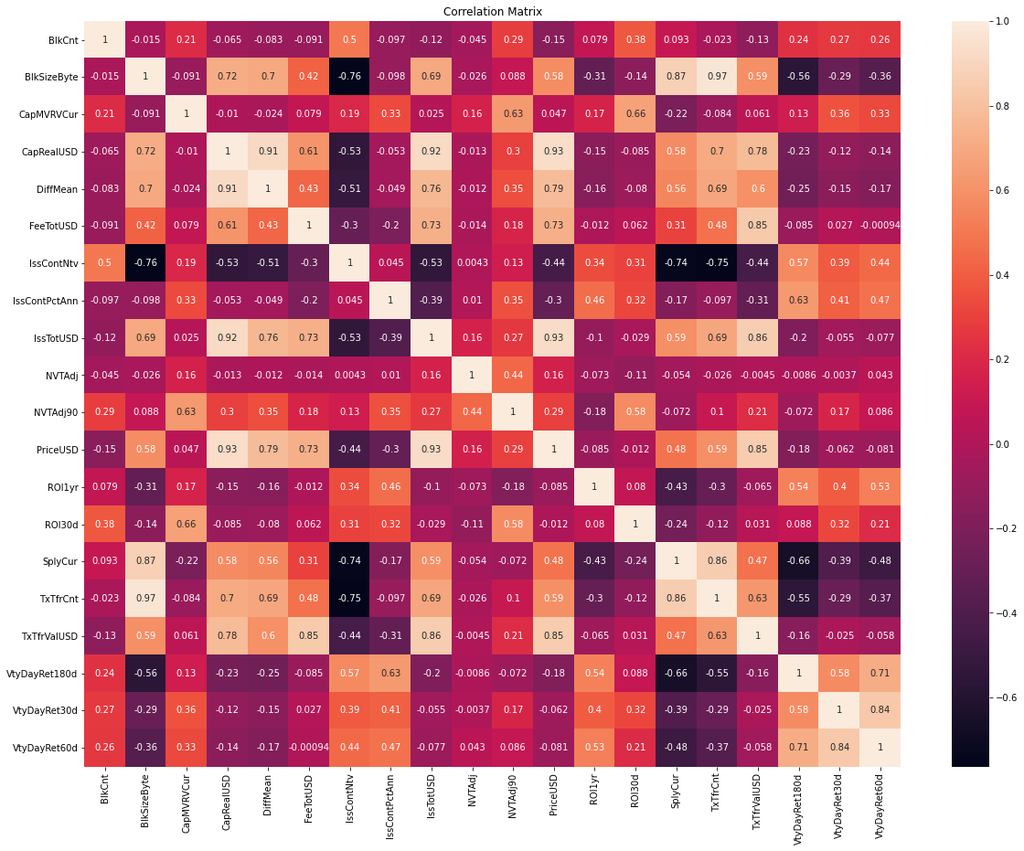

```python
corr_matrix = bitcoin_data1[num_cols1].corr()

f, ax = plt.subplots(figsize= [20,15])
sns.heatmap(corr_matrix, annot=True)
ax.set_title("Correlation Matrix")
f.show()
```

And let's display the corresponding correlations below.

```python
bitcoin_data1[bitcoin_data1.columns].corr()['ROI30d']
```

```
BlkCnt           0.381167
BlkSizeByte     -0.139260
CapMVRVCur       0.664956
CapRealUSD      -0.085189
DiffMean        -0.079744
FeeTotUSD        0.061533
IssContNtv       0.306539
IssContPctAnn    0.323280
IssTotUSD       -0.029202
NVTAdj          -0.106572
NVTAdj90         0.577110
PriceUSD        -0.012394
ROI1yr           0.079528
ROI30d           1.000000
SplyCur         -0.241706
TxTfrCnt        -0.121137
TxTfrValUSD      0.030594
VtyDayRet180d    0.088213
VtyDayRet30d     0.320363
VtyDayRet60d     0.211288
Name: ROI30d, dtype: float64
```

Here we see that the features CapMVRVCur and NVTAdj90 have the greatest correlation with our return on investment indicator. 0.664956 and 0.577110, respectively. It means that with an increase in these indicators, ROI30d also increases, and vice versa.

Let's illustrate these dependencies.

```python
btcCR = bitcoin_data1[["CapMVRVCur", "ROI30d", "NVTAdj90"]]
btcCR.dropna(inplace=True)
```

```python
fig = px.scatter(x=btcCR["CapMVRVCur"], y=btcCR["ROI30d"])
fig.update_layout(
    title="Dependence between Return on investment (30d) and CapMVRVCur",
    xaxis_title="CapMVRVCur",
    yaxis_title="ROI30d",
)
fig.show()
```

[interactive chart not shown]

```python
fig = px.scatter(x=btcCR["NVTAdj90"], y=btcCR["ROI30d"])
fig.update_layout(
    title="Dependence between Return on investment (30d) and CapMVRVCur",
    xaxis_title="CapMVRVCur",
    yaxis_title="NVTAdj90",
)
fig.show()
```

[interactive chart not shown]

Thus, the features "CapMVRVCur" and "NVTAdj90" definitely have an impact on our target attribute "ROI30d".

Let's explore which features have the greatest impact on the Return on investment indicator with the help of the Random Forest ML model. Perhaps, we will discover something new.

```python
data = bitcoin_data1[num_cols1]
data.head()
```

| date | BlkCnt | BlkSizeByte | CapMVRVCur | CapRealUSD | DiffMean | FeeTotUSD | IssContNtv | IssContPctAnn | IssTotUSD | NVTAdj | NVTAdj90 | PriceUSD | ROI1yr | ROI30d | SplyCur | TxTfrCnt | TxTfrValUSD | VtyDayRet180d | VtyDayRet30d | VtyDayRet60d |
| --- | --- | --- | --- | --- | --- | --- | --- | --- | --- | --- | --- | --- | --- | --- | --- | --- | --- | --- | --- | --- |
| 2009-01-03 | 0 | 0 | NaN | 0.0 | NaN | NaN | NaN | NaN | NaN | NaN | NaN | NaN | NaN | NaN | 0.0 | 0 | NaN | NaN | NaN | NaN |
| 2009-01-04 | 0 | 0 | NaN | 0.0 | NaN | NaN | NaN | NaN | NaN | NaN | NaN | NaN | NaN | NaN | 0.0 | 0 | NaN | NaN | NaN | NaN |
| 2009-01-05 | 0 | 0 | NaN | 0.0 | NaN | NaN | NaN | NaN | NaN | NaN | NaN | NaN | NaN | NaN | 0.0 | 0 | NaN | NaN | NaN | NaN |
| 2009-01-06 | 0 | 0 | NaN | 0.0 | NaN | NaN | NaN | NaN | NaN | NaN | NaN | NaN | NaN | NaN | 0.0 | 0 | NaN | NaN | NaN | NaN |
| 2009-01-07 | 0 | 0 | NaN | 0.0 | NaN | NaN | NaN | NaN | NaN | NaN | NaN | NaN | NaN | NaN | 0.0 | 0 | NaN | NaN | NaN | NaN |

```python
bitcoin_data1.info()
```

```
<class 'pandas.core.frame.DataFrame'>
DatetimeIndex: 4503 entries, 2009-01-03 to 2021-05-02
Data columns (total 20 columns):
 #   Column         Non-Null Count  Dtype
---  ------         --------------  -----
 0   BlkCnt         4503 non-null   int64
 1   BlkSizeByte    4503 non-null   int64
 2   CapMVRVCur     3942 non-null   float64
 3   CapRealUSD     4503 non-null   float64
 4   DiffMean       4497 non-null   float64
 5   FeeTotUSD      3942 non-null   float64
 6   IssContNtv     4497 non-null   float64
 7   IssContPctAnn  4497 non-null   float64
 8   IssTotUSD      3942 non-null   float64
 9   NVTAdj         4243 non-null   float64
 10  NVTAdj90       3853 non-null   float64
 11  PriceUSD       3942 non-null   float64
 12  ROI1yr         3577 non-null   float64
 13  ROI30d         3912 non-null   float64
 14  SplyCur        4503 non-null   float64
 15  TxTfrCnt       4503 non-null   int64
 16  TxTfrValUSD    3942 non-null   float64
 17  VtyDayRet180d  3762 non-null   float64
 18  VtyDayRet30d   3912 non-null   float64
 19  VtyDayRet60d   3882 non-null   float64
dtypes: float64(17), int64(3)
memory usage: 738.8 KB
```

```python
data.dropna(inplace=True)
data.info()
```

```
<class 'pandas.core.frame.DataFrame'>
DatetimeIndex: 3577 entries, 2011-07-18 to 2021-05-02
Data columns (total 20 columns):
 #   Column         Non-Null Count  Dtype
---  ------         --------------  -----
 0   BlkCnt         3577 non-null   int64
 1   BlkSizeByte    3577 non-null   int64
 2   CapMVRVCur     3577 non-null   float64
 3   CapRealUSD     3577 non-null   float64
 4   DiffMean       3577 non-null   float64
 5   FeeTotUSD      3577 non-null   float64
 6   IssContNtv     3577 non-null   float64
 7   IssContPctAnn  3577 non-null   float64
 8   IssTotUSD      3577 non-null   float64
 9   NVTAdj         3577 non-null   float64
 10  NVTAdj90       3577 non-null   float64
 11  PriceUSD       3577 non-null   float64
 12  ROI1yr         3577 non-null   float64
 13  ROI30d         3577 non-null   float64
 14  SplyCur        3577 non-null   float64
 15  TxTfrCnt       3577 non-null   int64
 16  TxTfrValUSD    3577 non-null   float64
 17  VtyDayRet180d  3577 non-null   float64
 18  VtyDayRet30d   3577 non-null   float64
 19  VtyDayRet60d   3577 non-null   float64
dtypes: float64(17), int64(3)
memory usage: 586.9 KB
```

```python
y = data["ROI30d"]
x = data.drop(["ROI30d","ROI1yr"], axis=1)
```

```python
from sklearn.ensemble.forest import RandomForestRegressor
import numpy as np
from sklearn.model_selection import train_test_split
```

```python
X_train, X_test, y_train, y_test = train_test_split(x, y, test_size=0.25, random_state=12)
```

```python
rf = RandomForestRegressor(n_estimators=1000)
rf.fit(X_train, y_train)
```

```
RandomForestRegressor(n_estimators=1000)
```

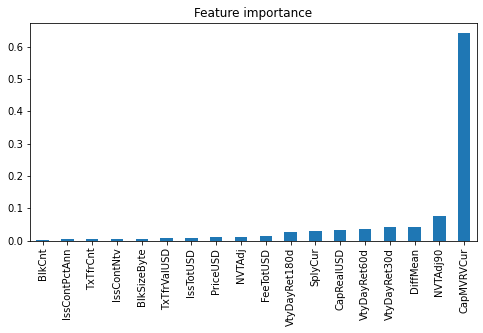

```python
f, ax = plt.subplots(figsize= [8,4])

weights = pd.Series(rf.feature_importances_, index=x.columns.values)
weights.sort_values().plot(kind = 'bar')

ax.set_title("Feature importance")
f.show()
```

Here we see the columns that contribute the most. Top features are again 'CapMVRVCur' and 'NVTAdj90.

```python
#sorted_idx = rf.feature_importances_.argsort()
#new_features = list(x.columns[sorted_idx][-15:].values)
#new_features
```

Let's explore how these indicators behave starting from 2021.

```python
fig = px.line(bitcoin_data[bitcoin_data.index > '2021-01-01'], x=bitcoin_data[bitcoin_data.index > '2021-01-01'].index, y="CapMVRVCur")
fig.update_layout(
    title="Changing CapMVRVCur over time",
    xaxis_title="date",
    yaxis_title="CapMVRVCur",
)

fig.show()
```

[interactive chart not shown]

```python
fig = px.line(bitcoin_data[bitcoin_data.index > '2021-01-01'], x=bitcoin_data[bitcoin_data.index > '2021-01-01'].index, y="NVTAdj90")
fig.update_layout(
    title="Changing NVTAdj90 over time",
    xaxis_title="date",
    yaxis_title="NVTAdj90",
)

fig.show()
```

[interactive chart not shown]

We see that these indicators have been declining since the beginning of the year. This means that we should expect a decrease in the ROI30d indicator.